# Prosjektoppgave GEO9300 - Hydrologic regime in Vosso and changes over time.

#### Background: https://www.nrk.no/vestland/pa-voss-har-det-vaert-fem-20-arsflommer-siste-atte-ar-1.16178538.

#### Voss has experienced five 20 year floods in the past 8 years (NRK, 2022). They claim the climate expected in 2100 has already reached them. Is that correct? How much has the hydrology changed the past 30 years for Voss?

#### Climate scenario modeling for Voss estimate that todays 1000 yr flood will be a 200 year flood in 2100.

#### Q:Can we see a change in the hydrologic regime of Voss the past 30 years, compared to the previous normal period?

##### Calculate basic statistic: yearly and monthly?

##### Determine high and low flow pulses: 75 % for high flow and 25 % for low flow.

##### Determine high and low flow durations.

##### Is there a significant difference in MAD (Mean annual discharge)

##### Libraries: HydroBox / Hydropy

#### Flood frequence analysis?

#### Q: What is the probability of getting 4 (or 5) 20 year flood in 8 years?

#### Can we simulate future discharge using a ML-model?

##### Input: climate data, CC (from GIS), ...

```python
#Libraries
import matplotlib.pyplot as plt
import numpy as np
import pandas as pd
import datetime
import scipy.stats as stats
from statsmodels.tsa.seasonal import seasonal_decompose
import math

%matplotlib inline

import warnings
warnings.filterwarnings('ignore')
```

### Prepare data and describe data

#### 2) Flood values

#### 3) Percentiles

```python
#1)  Read the discharge data
vf = pd.read_csv('BulkenDognVerdier.csv', delimiter=';', on_bad_lines='skip', skiprows=[0])

# Convert comma to period in Vannføring column and convert to float
vf['Vannføring'] = vf['Vannføring'].str.replace(',', '.').astype(float)

# Split into two time periods
vf1 = vf[(vf['Tidspunkt'] >= '1991-01-01') & (vf['Tidspunkt'] <= '2020-12-31')].copy()
vf2 = vf[(vf['Tidspunkt'] >= '1961-01-01') & (vf['Tidspunkt'] <= '1990-12-31')].copy()
vf3 = vf[(vf['Tidspunkt'] >= '1961-01-01') & (vf['Tidspunkt'] <= '2020-12-31')].copy()

# Convert Tidspunkt to datetime
vf1['Tidspunkt'] = pd.to_datetime(vf1['Tidspunkt'])
vf2['Tidspunkt'] = pd.to_datetime(vf2['Tidspunkt'])
vf3['Tidspunkt'] = pd.to_datetime(vf3['Tidspunkt'])
vf['Tidspunkt'] = pd.to_datetime(vf['Tidspunkt'])

# Set Tidspunkt as index for both dataframes
vf1.set_index('Tidspunkt', inplace=True)
vf2.set_index('Tidspunkt', inplace=True)
vf3.set_index('Tidspunkt', inplace=True)
vf.set_index('Tidspunkt', inplace=True)

# Sort by time
vf1.sort_index(inplace=True)
vf2.sort_index(inplace=True)
vf3.sort_index(inplace=True)
vf.sort_index(inplace=True)

# Display the results
print("\nFirst rows of vf1 (1991-2020):")
print(vf1.head())
print("\nFirst rows of vf2 (1961-1990):")
print(vf2.head())

#2) Read flood values
flomverdier = pd.read_csv('flomverdier.csv', delimiter=';', on_bad_lines='skip', skiprows=[0])
print(flomverdier.head())
```

```
First rows of vf1 (1991-2020):
                           Vannføring  Korrigert  Kontrollert
Tidspunkt
1991-01-01 11:00:00+00:00    27.90077          0            3
1991-01-02 11:00:00+00:00    24.30701          0            3
1991-01-03 11:00:00+00:00    23.61584          0            3
1991-01-04 11:00:00+00:00    22.93392          0            3
1991-01-05 11:00:00+00:00    22.26125          0            3

First rows of vf2 (1961-1990):
                           Vannføring  Korrigert  Kontrollert
Tidspunkt
1961-01-01 11:00:00+00:00    8.919145          0            3
1961-01-02 11:00:00+00:00    8.681128          0            3
1961-01-03 11:00:00+00:00    9.161231          0            3
1961-01-04 11:00:00+00:00    8.681128          0            3
1961-01-05 11:00:00+00:00    7.551074          0            3
        Middelflom  400
0   Flomverdi 5 år  470
1  Flomverdi 10 år  530
2  Flomverdi 20 år  580
3  Flomverdi 50 år  660
```

### Visialize the data.

#### Discharge data.

Probability density function of a continuous random variable.

Must be f(x) >= 0 for all xi. Integral of f(x) dx = 1 for the whole range.

Remember: continuous functions have probability densitys.

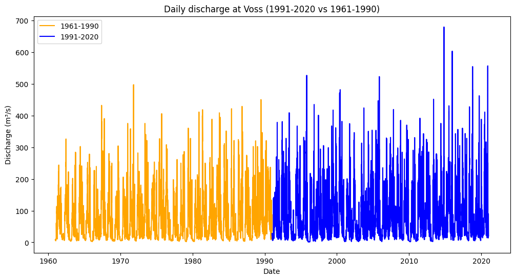

[figure not shown]

```python
#Plot visualizing the timeseries.
plt.figure(figsize=(12,6))
plt.plot(vf2['Vannføring'], label='1961-1990', color='orange')
plt.plot(vf1['Vannføring'], label='1991-2020', color='blue')
plt.xlabel('Date')
plt.ylabel('Discharge (m³/s)')
plt.title('Daily discharge at Voss (1991-2020 vs 1961-1990)')
plt.legend()
plt.show()

plt.figure(figsize=(12,6))
plt.plot(vf['Vannføring'], color='blue')
#plt.plot(vf2['Vannføring'], label='1961-1990', color='orange')
plt.xlabel('Date')
plt.ylabel('Discharge (m³/s)')
plt.title('Daily discharge at Voss (1991-2020 vs 1961-1990)')
plt.legend()
plt.show()
```

Just from looking at the graph, we notice that there are a couple higher flood peaks in the later period than the first.

[figure not shown]

```python
#Plot 2012-2020 with flomverdier
plt.figure(figsize=(12,6))

# Filter data for 2012-2020
vf1_filtered = vf1['2010':'2020']  # Using pandas datetime slicing

# Plot the filtered data
plt.plot(vf1_filtered['Vannføring'], color='blue', label='Vannføring')

# Add horizontal lines
plt.axhline(y=530, color='orange', linestyle='--', label='10 årsflom')
plt.axhline(y=580, color='g', linestyle='--', label='20 årsflom')
plt.axhline(y=660, color='r', linestyle='--', label='50 årsflom')

plt.xlabel('Date')
plt.ylabel('Vannføring (m³/s)')
plt.title('Daily Vannføring with Flomverdier (2012-2020)')
plt.legend(loc='upper left')
plt.grid(True)
plt.show()

#NB: we have daily data but the flood values are for instantaneous peak discharge.
```

### DISTRIBUTION OF DATA AND CHECK FOR LINEARITY

#### Is the data normally distributed? What is the mean and std of each population?

#### Q: Why is this important?

"Hydrologists are often faced with large quantities of data. Since it is difficult to grasp the total data picture from tabulation, a useful first step in data analysis is to use graphical procedures. Frequency histogram is a graphical presentation of the data. This is done by grouping the data into classes and then plotting a bar graph with the number or the relative frequency (proportion) of observations in a class versus the midpoint (called class mark) of the class interval. 14 Cumulative frequency distribution shows the frequency of events less than (greater than) some given value. They are formed by ranking the data from the smallest (largest) to the largest (smallest), dividing the rank by the number of data points and plotting this ratio against the corresponding data value" (Compendium)

#### Normal distribution

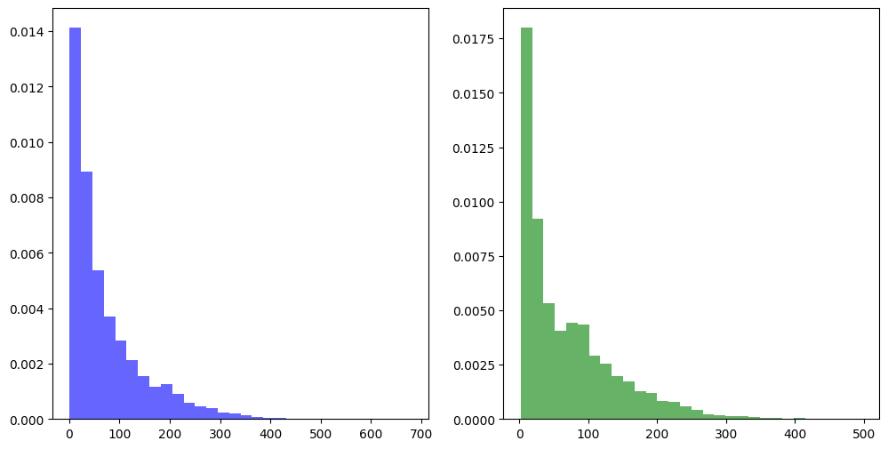

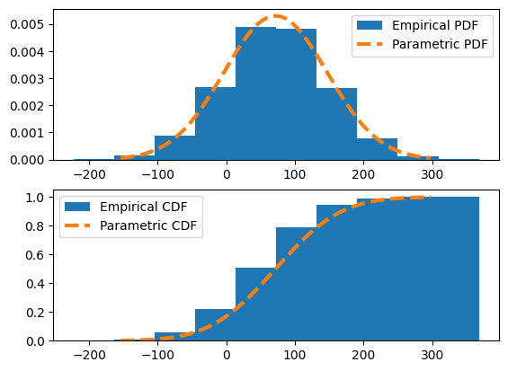

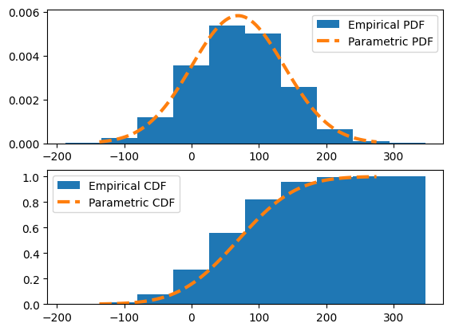

```python
#Plot histogram of vf1 and vf2
plt.figure(figsize=(12,6))
plt.subplot(1, 2, 1)
plt.hist(vf1['Vannføring'], bins=30, density=True, alpha=0.6, color='b')


plt.subplot(1, 2, 2)
plt.hist(vf2['Vannføring'], bins=30, density=True, alpha=0.6, color='g')

# Plot the normal distribution curve and check how our generated sample fit the curve

population_mean = vf1['Vannføring'].mean()
population_std = vf1['Vannføring'].std()
samplesize= len(vf1)

rv1 = np.random.normal(loc=population_mean, scale=population_std, size=samplesize)

fig=plt.figure()
ax1=fig.add_subplot(211) #for pdfs
ax2=fig.add_subplot(212, sharex=ax1) #for cdfs

ax1.hist(rv1, density = True, label='Empirical PDF')
ax2.hist(rv1, density = True, cumulative=True, label='Empirical CDF')

# To plot the underlaying Gaussian, we use the stats package
x = np.linspace(population_mean-3*population_std,population_mean+3*population_std,1000)
ax1.plot(x, stats.norm.pdf(x, population_mean, population_std), '--', linewidth=3, label='Parametric PDF')
ax1.legend()

ax2.plot(x, stats.norm.cdf(x, population_mean, population_std), '--', linewidth=3, label='Parametric CDF')
ax2.legend()

# Plot the normal distribution curve and check how our generated sample fit the curve

population_mean = vf2['Vannføring'].mean()
population_std = vf2['Vannføring'].std()
samplesize= len(vf2)

rv1 = np.random.normal(loc=population_mean, scale=population_std, size=samplesize)

fig=plt.figure()
ax1=fig.add_subplot(211) #for pdfs
ax2=fig.add_subplot(212, sharex=ax1) #for cdfs

ax1.hist(rv1, density = True, label='Empirical PDF')
ax2.hist(rv1, density = True, cumulative=True, label='Empirical CDF')

# To plot the underlaying Gaussian, we use the stats package
x = np.linspace(population_mean-3*population_std,population_mean+3*population_std,100)
ax1.plot(x, stats.norm.pdf(x, population_mean, population_std), '--', linewidth=3, label='Parametric PDF')
ax1.legend()

ax2.plot(x, stats.norm.cdf(x, population_mean, population_std), '--', linewidth=3, label='Parametric CDF')
ax2.legend()
```

Not sure the these last figures are correct. The values should not be less than 0?

#### Properties

he coefficient of variation measures the spread of a set of data as a proportion of its mean. It is often expressed as a percentage. It is dimensionless, so it can be used for cross comparison, i.e. for comparison of the variability of the same variable at different places, etc. It is the ratio of the sample standard deviation to the sample mean:

```python
#Properties of random variables.

#Central tendency measures: mean, median, mode
mean_vf1 = vf1['Vannføring'].mean()
median_vf1 = vf1['Vannføring'].median()
mode_vf1 = vf1['Vannføring'].mode()[0]

print("Mean:", mean_vf1, "Median", median_vf1, "Mode", mode_vf1)

mean_vf2 = vf2['Vannføring'].mean()
median_vf2 = vf2['Vannføring'].median()
mode_vf2 = vf2['Vannføring'].mode()[0]

print("Mean", mean_vf2, "Median", median_vf2,"Mode", mode_vf2)

#Dispersion measures: variance, standard deviation, range, interquartile range
variance_vf1 = vf1['Vannføring'].var()
std_dev_vf1 = vf1['Vannføring'].std()
range_vf1 = vf1['Vannføring'].max() - vf1['Vannføring'].min()
#iqr_vf1 = vf1['Vannføring'].quantile(0.75) - vf1['Vannføring'].quantile(0.25)
print("Variance:", variance_vf1, "Std:", std_dev_vf1, "Range:", range_vf1, "Coeff of variation:", std_dev_vf1/mean_vf1)

variance_vf2 = vf2['Vannføring'].var()
std_dev_vf2 = vf2['Vannføring'].std()
range_vf2 = vf2['Vannføring'].max() - vf2['Vannføring'].min()
#iqr_vf1 = vf1['Vannføring'].quantile(0.75) - vf1['Vannføring'].quantile(0.25)
print("Variance:", variance_vf2, "Std:", std_dev_vf2, "Range:", range_vf2, "Coeff of variation:", std_dev_vf2/mean_vf2)

#Symmertry measures: skewness, kurtosis
skewness_vf1 = vf1['Vannføring'].skew()
kurtosis_vf1 = vf1['Vannføring'].kurtosis()
print("Skewness:", skewness_vf1, "Kurtosis:", kurtosis_vf1)
skewness_vf2 = vf2['Vannføring'].skew()
kurtosis_vf2 = vf2['Vannføring'].kurtosis()
print("Skewness:", skewness_vf2, "Kurtosis:", kurtosis_vf2)
```

```
Mean: 71.57862097426302 Median 43.4978 Mode 13.29744
Mean 68.8417495530303 Median 43.801 Mode 17.70476
Variance: 5672.706418895384 Std: 75.31737129570696 Range: 678.837531 Coeff of variation: 1.052232779432678
Variance: 4701.3333918369835 Std: 68.566270073827 Range: 495.598459 Coeff of variation: 0.9959983660933677
Skewness: 1.8813262175851566 Kurtosis: 4.463582936306628
Skewness: 1.469787147454497 Kurtosis: 2.2931018262239125
```

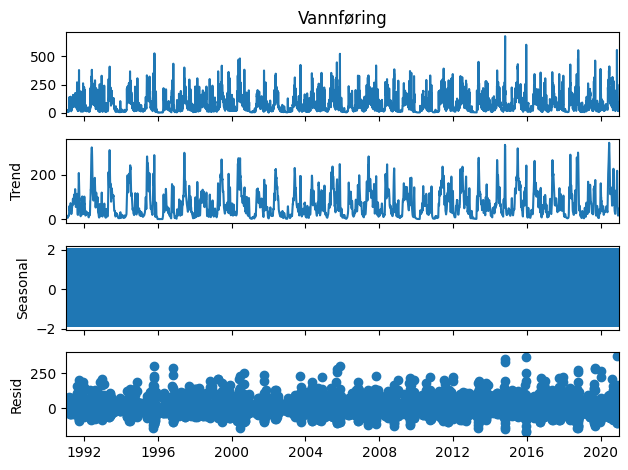

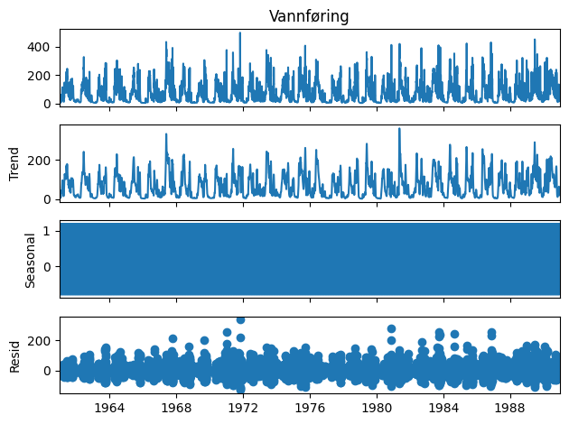

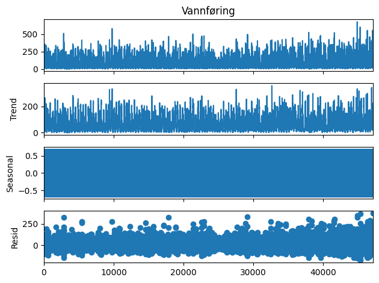

```python
# In some cases, a simple decomposition using moving averages can already be informative
# here, assuming an additive model: Y[t] = T[t] + S[t] + e[t]
# and a 12-months periodicity
decomposition=seasonal_decompose(vf1['Vannføring'], model='additive', period=12).plot()
decomposition=seasonal_decompose(vf2['Vannføring'], model='additive', period=12).plot()

decomposition=seasonal_decompose(vf['Vannføring'], model='additive', period=12).plot()

#this decomposition can be regarded as a model that produces the observed data

#For daily values this does not give that much information...
```

## Test for linearity i.e. is there trend in the dataset

```python
from statsmodels.sandbox.stats.runs import runstest_1samp

z, p_value = runstest_1samp(vf1['Vannføring'], cutoff='mean', correction=False)
print(f'Runstest for vf1 (1991-2020): z={z}, p-value={p_value}')
z, p_value = runstest_1samp(vf2['Vannføring'])
print(f'Runstest for vf2 (1961-1990): z={z}, p-value={p_value}')

#Investigate if there is signifcant trend in Q over years using linear regrisson method
```

```
Runstest for vf1 (1991-2020): z=-88.54675699266188, p-value=0.0
Runstest for vf2 (1961-1990): z=-93.17609907225244, p-value=0.0
```

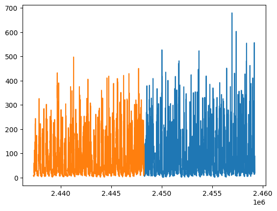

```python
#Test linerairy (for daily values this is not that informative...)

vf1['julian_date'] = vf1.index.to_julian_date()
vf1.head()

from statsmodels.formula.api import ols

plt.plot(vf1['julian_date'], vf1['Vannføring'])

model = ols("Vannføring ~ julian_date", vf1).fit()
#print(model.summary())

vf2['julian_date'] = vf2.index.to_julian_date()
vf2.head()

from statsmodels.formula.api import ols

plt.plot(vf2['julian_date'], vf2['Vannføring'])

model = ols("Vannføring ~ julian_date", vf2).fit()
#print(model.summary())
```

```python
#%pip install hydropy hydrobox

# Compatibility shim: some older packages expect pandas.datetools which was removed in recent pandas.
# Attach pandas.tseries (or a simple namespace) to pd.datetools so imports like "import pandas.datetools"
# don't raise AttributeError.
if not hasattr(pd, 'datetools'):
	try:
		pd.datetools = pd.tseries
	except Exception:
		import types
		pd.datetools = types.SimpleNamespace()

import hydropy as hp
import hydrobox as hb

#### 1) Can we see a change in the hydrologic regime of Voss the past 30 years, compared to the previous normal period?

##### Calculate basic statistic: yearly and monthly?
##### Determine high and low flow pulses: 75 % for high flow and 25 % for low flow.
##### Determine high and low flow durations.
##### Libraries: HydroBox / Hydropy

# Reset index to make Tidspunkt a column
vf1 = vf1.reset_index()
vf1['Tidspunkt'] = pd.to_datetime(vf1['Tidspunkt']).dt.tz_localize(None)
vf1.set_index('Tidspunkt', inplace=True)
print(vf1.index.tz)

vf2 = vf2.reset_index()
vf2['Tidspunkt'] = pd.to_datetime(vf2['Tidspunkt']).dt.tz_localize(None)
vf2.set_index('Tidspunkt', inplace=True)
print(vf2.index.tz)

#Libraries
myflowserie = hp.HydroAnalysis(vf1['Vannføring'])
myflowserie2 = hp.HydroAnalysis(vf2['Vannføring'])

#print(myflowserie.head())
#print(myflowserie2.head())

print("Period 1:", myflowserie.data.groupby('season').mean())
print("Period 2:", myflowserie2.data.groupby('season').mean())

print("Period 1:", myflowserie.data.groupby('season').max())
print("Period 2:", myflowserie2.data.groupby('season').max())

print("Period 1:", myflowserie.data.groupby('season').min())
print("Period 2:", myflowserie2.data.groupby('season').min())
#myflowserie.get_year('2009').get_season('summer').plot(figsize=(12,6))


# Convert pandas DataFrame to hydropy Series
#ts = hp.HySeries(vf1['Vannføring'], index=vf1.index)

# Now you can use hydropy methods
#ts_2011 = ts.get_year('2011')
#ts_2011_jun = ts_2011.get_month("Jun")
#ts_2011_jun.get_recess()

#season = get_season(vf1.index.month)  # Function to determine season based on month
#vf1['Season'] = season
```

[output not shown]

# Flood frequency analysis. Annual maximum discharge.

```python
#First I need to extract annual maximum series for both time periods
vf1_annual_max = vf1.resample('Y').max()
vf2_annual_max = vf2.resample('Y').max()
vf3_annual_max = vf3.resample('Y').max() #I will use this in the analysis bc I need to include both periods to see if there is a trend.

#print("\nAnnual maximum series for vf1 (1991-2020):")
#print(vf1_annual_max.head())
#print("\nAnnual maximum series for vf2 (1961-1990):")
#print(vf2_annual_max)
```

## Weibull probabilities for the two different periods.

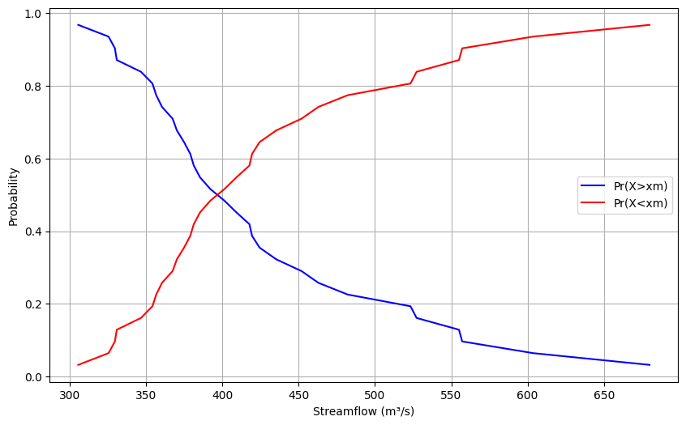

```python
#vf1_annual_max: 1991-2020

# Sort the values and create a new sorted series
sorted_values = vf1_annual_max['Vannføring'].sort_values(ascending=False)
#vf1_annual_max['sorted_values'] = vf1_annual_max['Vannføring'].sort_values(ascending=False)
vf1_annual_max = vf1_annual_max.sort_values(by='Vannføring', ascending=False)
vf1_annual_max['Sorted'] = sorted_values.values
#print("After sorting:")
#print(vf1_annual_max.head())

# Add ranks
vf1_annual_max["Rank"] = np.arange(1,31,1)
#print("\nAfter adding ranks:")
#print(vf1_annual_max.head())

#Weibull probability
N = 30
vf1_annual_max["Prob"] = vf1_annual_max["Rank"]/(N+1)
#print("\nAfter adding probabilities:")
#print(vf1_annual_max.head())

# Create the plot
plt.figure(figsize=(10,6))
plt.plot(vf1_annual_max["Sorted"], vf1_annual_max["Prob"], 'b-', label='Pr(X>xm)')
plt.plot(vf1_annual_max["Sorted"], 1 - vf1_annual_max["Prob"], 'r-', label='Pr(X<xm)')
plt.ylabel("Probability")
plt.xlabel("Streamflow (m³/s)")
plt.grid(True)
plt.legend()
plt.show()

#The highest flood recordet has a prob of 0.033, meaning a return period of 30 years..
```

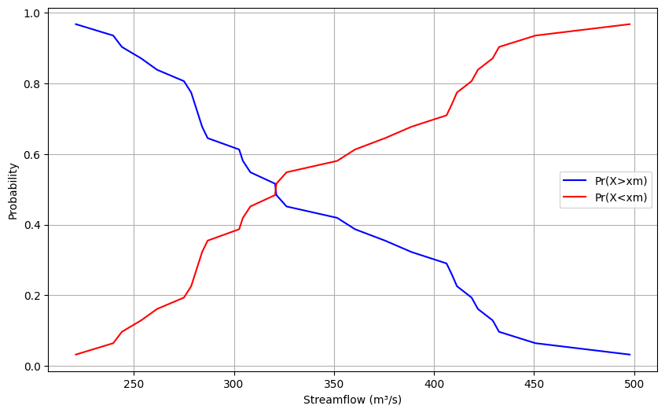

```python
#vf2_annual_max: 1960-2091

# Sort the values and create a new sorted series
sorted_values = vf2_annual_max['Vannføring'].sort_values(ascending=False)
#vf1_annual_max['sorted_values'] = vf1_annual_max['Vannføring'].sort_values(ascending=False)
vf2_annual_max = vf2_annual_max.sort_values(by='Vannføring', ascending=False)
vf2_annual_max['Sorted'] = sorted_values.values
#print("After sorting:")
#print(vf2_annual_max.head())

# Add ranks
vf2_annual_max["Rank"] = np.arange(1,31,1)
#print("\nAfter adding ranks:")
#print(vf2_annual_max.head())

#Weibull probability
N = 30
vf2_annual_max["Prob"] = vf2_annual_max["Rank"]/(N+1)
#print("\nAfter adding probabilities:")
#print(vf2_annual_max.head())

# Create the plot
plt.figure(figsize=(10,6))
plt.plot(vf2_annual_max["Sorted"], vf2_annual_max["Prob"], 'b-', label='Pr(X>xm)')
plt.plot(vf2_annual_max["Sorted"], 1 - vf2_annual_max["Prob"], 'r-', label='Pr(X<xm)')
plt.ylabel("Probability")
plt.xlabel("Streamflow (m³/s)")
plt.grid(True)
plt.legend()
plt.show()

#The highest flood recordet has a prob of 0.033, meaning a return period of 30 years..?
```

# Distribution of annual maximum values

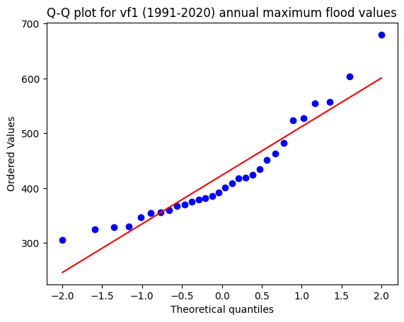

```
Mean vf3 annual max: 380.9005149999999
Std vf3 annual max: 92.27885785034223
Mean vf1 annual max: 423.61845666666653
Std vf1 annual max: 90.134578291539
Mean vf2 annual max: 338.1825733333334
Std vf2 annual max: 73.65237370977322
```

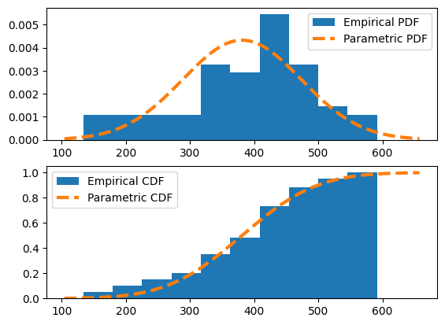

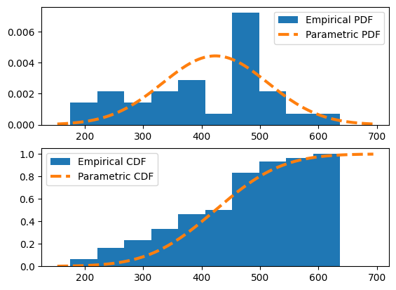

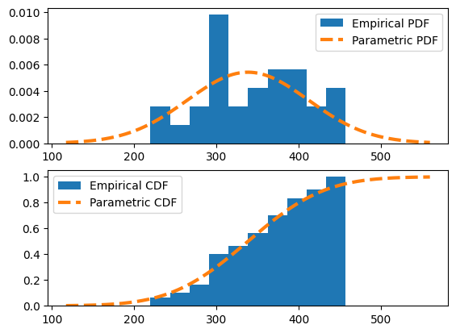

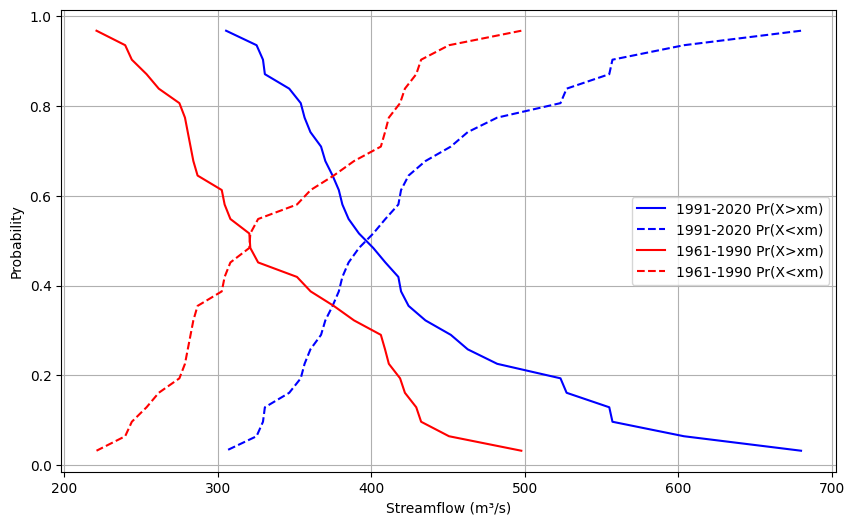

```python
#Is the maximum flood values normally distributed? Q-Q plot
stats.probplot(vf1_annual_max['Vannføring'], dist="norm", plot=plt)
plt.title('Q-Q plot for vf1 (1991-2020) annual maximum flood values')
plt.show()


# Plot the normal distribution curve and check how our generated sample fit the curve

population_mean = vf3_annual_max['Vannføring'].mean()
population_std = vf3_annual_max['Vannføring'].std()
samplesize= len(vf3_annual_max)

print("Mean vf3 annual max:", population_mean)
print("Std vf3 annual max:", population_std)

rv1 = np.random.normal(loc=population_mean, scale=population_std, size=samplesize)

fig=plt.figure()
ax1=fig.add_subplot(211) #for pdfs
ax2=fig.add_subplot(212, sharex=ax1) #for cdfs

ax1.hist(rv1, density = True, label='Empirical PDF')
ax2.hist(rv1, density = True, cumulative=True, label='Empirical CDF')

# To plot the underlaying Gaussian, we use the stats package
x = np.linspace(population_mean-3*population_std,population_mean+3*population_std,1000)
ax1.plot(x, stats.norm.pdf(x, population_mean, population_std), '--', linewidth=3, label='Parametric PDF')
ax1.legend()

ax2.plot(x, stats.norm.cdf(x, population_mean, population_std), '--', linewidth=3, label='Parametric CDF')
ax2.legend()

# Plot the normal distribution curve and check how our generated sample fit the curve

population_mean = vf1_annual_max['Vannføring'].mean()
population_std = vf1_annual_max['Vannføring'].std()
samplesize= len(vf1_annual_max)

print("Mean vf1 annual max:", population_mean)
print("Std vf1 annual max:", population_std)

rv1 = np.random.normal(loc=population_mean, scale=population_std, size=samplesize)

fig=plt.figure()
ax1=fig.add_subplot(211) #for pdfs
ax2=fig.add_subplot(212, sharex=ax1) #for cdfs

ax1.hist(rv1, density = True, label='Empirical PDF')
ax2.hist(rv1, density = True, cumulative=True, label='Empirical CDF')

# To plot the underlaying Gaussian, we use the stats package
x = np.linspace(population_mean-3*population_std,population_mean+3*population_std,1000)
ax1.plot(x, stats.norm.pdf(x, population_mean, population_std), '--', linewidth=3, label='Parametric PDF')
ax1.legend()

ax2.plot(x, stats.norm.cdf(x, population_mean, population_std), '--', linewidth=3, label='Parametric CDF')
ax2.legend()

# Plot the normal distribution curve and check how our generated sample fit the curve

population_mean = vf2_annual_max['Vannføring'].mean()
population_std = vf2_annual_max['Vannføring'].std()
samplesize= len(vf2_annual_max)

print("Mean vf2 annual max:", population_mean)
print("Std vf2 annual max:", population_std)

rv1 = np.random.normal(loc=population_mean, scale=population_std, size=samplesize)

fig=plt.figure()
ax1=fig.add_subplot(211) #for pdfs
ax2=fig.add_subplot(212, sharex=ax1) #for cdfs

ax1.hist(rv1, density = True, label='Empirical PDF')
ax2.hist(rv1, density = True, cumulative=True, label='Empirical CDF')

# To plot the underlaying Gaussian, we use the stats package
x = np.linspace(population_mean-3*population_std,population_mean+3*population_std,1000)
ax1.plot(x, stats.norm.pdf(x, population_mean, population_std), '--', linewidth=3, label='Parametric PDF')
ax1.legend()

ax2.plot(x, stats.norm.cdf(x, population_mean, population_std), '--', linewidth=3, label='Parametric CDF')
ax2.legend()

#Flood value distribution for both periods on same plot
plt.figure(figsize=(10,6))
plt.plot(vf1_annual_max["Sorted"], vf1_annual_max["Prob"], 'b-', label='1991-2020 Pr(X>xm)')
plt.plot(vf1_annual_max["Sorted"], 1 - vf1_annual_max["Prob"], 'b--', label='1991-2020 Pr(X<xm)')
plt.plot(vf2_annual_max["Sorted"], vf2_annual_max["Prob"], 'r-', label='1961-1990 Pr(X>xm)')
plt.plot(vf2_annual_max["Sorted"], 1 - vf2_annual_max["Prob"], 'r--', label='1961-1990 Pr(X<xm)')
plt.ylabel("Probability")
plt.xlabel("Streamflow (m³/s)")
plt.grid(True)
plt.legend()
plt.show()
```

## Calculate the flood frequency

```python
#Frequency factor method
# Magnitude of 100-yr flow = 0.01

# 1) ... using Normal distribution
#Find mean and std from data:
skew1 = stats.skew(vf1_annual_max["Vannføring"])
skew2 = stats.skew(vf2_annual_max["Vannføring"])
print("The skewness of the period from 1921-1990 data is:", skew1)
print("The skewness of the period from 1961-1990 data is:", skew2)

#Period 1: VF1 = 1.12
mean = vf1_annual_max["Vannføring"].mean()
std = vf1_annual_max["Vannføring"].std()

Kt_list = [1.341, 2.006, 3.087]

Qt_normal_list = []  # store results

for Kt in Kt_list:
    Qt_normal = mean + (Kt * std)  # compute flood discharge for each Kt
    Qt_normal_list.append(Qt_normal)

print("Period1: Flood discharge estimates for a 10 year flood:", Qt_normal_list[0], "25 year flood", Qt_normal_list[1], "50 year flood", Qt_normal_list[2])

#VF2 = 0.33
mean = vf2_annual_max["Vannføring"].mean()
std = vf2_annual_max["Vannføring"].std()
Kt_list = [1.309, 1.849, 2.211]

Qt_normal_list = []  # store results

for Kt in Kt_list:
    Qt_normal = mean + (Kt * std)  # compute flood discharge for each Kt
    Qt_normal_list.append(Qt_normal)

print("Period2: Flood discharge estimates for a 10 year flood:", Qt_normal_list[0], "25 year flood", Qt_normal_list[1], "50 year flood", Qt_normal_list[2])

# 2) ... using Log-normal distribution
# Period 1:
log_data = np.log(vf1_annual_max["Vannføring"])
log_mean = log_data.mean()
log_std = log_data.std()

Kt_list = [1.341, 2.006, 3.087]

Qt_lognormal_list = []  # store results

for Kt in Kt_list:
    Qt_lognormal = log_mean + (Kt * log_std)
    Qt_lognormal_normal = math.exp(Qt_lognormal)
    Qt_lognormal_list.append(Qt_lognormal_normal)
print("Period1 (log-normal): Flood discharge estimates for a 10 year flood:", Qt_lognormal_list[0], "25 year flood", Qt_lognormal_list[1], "50 year flood", Qt_lognormal_list[2])

#Period 2:
log_data = np.log(vf2_annual_max["Vannføring"])
log_mean = log_data.mean()
log_std = log_data.std()

Kt_list = [1.309, 1.849, 2.211]

Qt_lognormal_list = []  # store results

for Kt in Kt_list:
    Qt_lognormal = log_mean + (Kt * log_std)
    Qt_lognormal_normal = math.exp(Qt_lognormal)
    Qt_lognormal_list.append(Qt_lognormal_normal)
print("Period2 (log-normal): Flood discharge estimates for a 10 year flood:", Qt_lognormal_list[0], "25 year flood", Qt_lognormal_list[1], "50 year flood", Qt_lognormal_list[2])

#3) Extreme-value type I (Gumbel) distribution
#Calculate Kt for Gumbel distribution
#Period 1:

mean = vf1_annual_max["Vannføring"].mean()
std = vf1_annual_max["Vannføring"].std()

def calculate_K_T(T):
    if T <= 1:
        raise ValueError("T must be greater than 1 to avoid division by zero.")
    inner_ln = math.log(T / (T - 1))
    outer_ln = math.log(inner_ln)
    K_T = - (math.sqrt(6) / math.pi) * (0.5772156649 + outer_ln)
    return K_T

Kt_gumbel_10 = calculate_K_T(10)
Kt_gumbel_25 = calculate_K_T(25)
Kt_gumbel_50 = calculate_K_T(50)

Qt_gumbel_10 = mean + (Kt_gumbel_10 * std)
Qt_gumbel_25 = mean + (Kt_gumbel_25 * std)
Qt_gumbel_50 = mean + (Kt_gumbel_50 * std)

print("Period1 (Gumbel): 10-yr:", Qt_gumbel_10, "25-yr:", Qt_gumbel_25, "50-yr:", Qt_gumbel_50)

#Period 2:
mean = vf2_annual_max["Vannføring"].mean()
std = vf2_annual_max["Vannføring"].std()

Kt_gumbel_10 = calculate_K_T(10)
Kt_gumbel_25 = calculate_K_T(25)
Kt_gumbel_50 = calculate_K_T(50)

Qt_gumbel_10 = mean + (Kt_gumbel_10 * std)
Qt_gumbel_25 = mean + (Kt_gumbel_25 * std)
Qt_gumbel_50 = mean + (Kt_gumbel_50 * std)

print("Period2 (Gumbel): 10-yr:", Qt_gumbel_10, "25-yr:", Qt_gumbel_25, "50-yr:", Qt_gumbel_50)

# 4) ... using Pearson III distribution

alfa = vf1_annual_max["Vannføring"].mean()
beta = vf1_annual_max["Vannføring"].std()
X = vf1_annual_max["Vannføring"]
n = 30

def cs(X, alfa, beta):

    numerator = n * np.sum((X - alfa) ** 3)
    denominator = (n - 1) * (n - 2) * (beta ** 3)

    return numerator / denominator

cs(X,alfa,beta)

Kt_list = [1.341, 2.006, 3.087]

Qt_pearson_list = []  # store results

for Kt in Kt_list:
    Qt_pearson = alfa + (Kt * beta)  # compute flood discharge for each Kt
    Qt_pearson_list.append(Qt_normal)

print("Period1 (Pearson): Flood discharge estimates for a 10 year flood:", Qt_normal_list[0], "25 year flood", Qt_normal_list[1], "50 year flood", Qt_normal_list[2])
```

[output not shown]

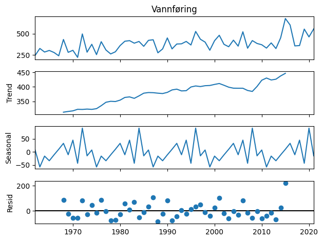

```python
# In some cases, a simple decomposition using moving averages can already be informative
# here, assuming an additive model: Y[t] = T[t] + S[t] + e[t]
# and a 12-months periodicity
decomposition=seasonal_decompose(vf3_annual_max['Vannføring'], model='additive', period=12).plot()


#decomposition=seasonal_decompose(vf3_over_400['Vannføring'], model='additive', period=12).plot()

#this decomposition can be regarded as a model that produces the observed data
```

# Peak over threshold.

```
Number of days where disharge is > 220                            Count  Vannføring
Tidspunkt
1961-06-09 00:00:00+00:00      1    222.7352
1961-06-25 00:00:00+00:00      1    244.0600
1961-06-26 00:00:00+00:00      1    222.7352
1962-06-19 00:00:00+00:00      1    235.4476
1962-06-20 00:00:00+00:00      1    252.7811
...                          ...         ...
2020-11-19 00:00:00+00:00      1    557.1242
2020-11-20 00:00:00+00:00      1    362.1890
2020-11-21 00:00:00+00:00      1    221.2694
2020-11-25 00:00:00+00:00      1    230.4615
2020-11-26 00:00:00+00:00      1    251.6336

[1086 rows x 2 columns]
<pandas.core.groupby.generic.DataFrameGroupBy object at 0x753f4266b140>
Streak 1: 1961-06-09 → 1961-06-09 (1 days)
Streak 2: 1961-06-25 → 1961-06-26 (2 days)
Streak 3: 1962-06-19 → 1962-06-26 (8 days)
Streak 4: 1962-10-26 → 1962-10-26 (1 days)
Streak 5: 1963-09-27 → 1963-09-28 (2 days)
Streak 6: 1963-10-12 → 1963-10-13 (2 days)
Streak 7: 1963-10-22 → 1963-10-23 (2 days)
Streak 8: 1964-05-09 → 1964-05-10 (2 days)
Streak 9: 1964-06-09 → 1964-06-09 (1 days)
Streak 10: 1964-06-15 → 1964-06-18 (4 days)
Streak 11: 1964-07-29 → 1964-07-29 (1 days)
Streak 12: 1964-08-25 → 1964-08-25 (1 days)
Streak 13: 1965-06-17 → 1965-06-18 (2 days)
Streak 14: 1965-06-21 → 1965-06-23 (3 days)
Streak 15: 1965-09-17 → 1965-09-17 (1 days)
Streak 16: 1965-09-22 → 1965-09-23 (2 days)
Streak 17: 1965-10-30 → 1965-11-01 (3 days)
Streak 18: 1966-05-20 → 1966-05-20 (1 days)
Streak 19: 1966-06-06 → 1966-06-06 (1 days)
Streak 20: 1966-09-07 → 1966-09-08 (2 days)
Streak 21: 1967-05-26 → 1967-06-08 (14 days)
Streak 22: 1967-06-16 → 1967-06-24 (9 days)
Streak 23: 1967-06-30 → 1967-07-02 (3 days)
Streak 24: 1967-07-11 → 1967-07-13 (3 days)
```

[output cut: 393 more lines]

```
47  2008                 7
48  2009                 7
49  2010                 3
50  2011                10
51  2012                10
52  2013                 6
53  2014                 6
54  2015                12
55  2016                 5
56  2017                 7
57  2018                 8
58  2019                 5
59  2020                 9
Mean vf3 annual max: 5.683333333333334
Std vf3 annual max: 2.8788631623167906
```

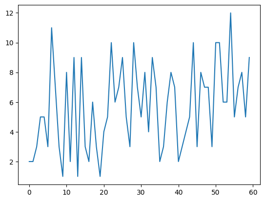

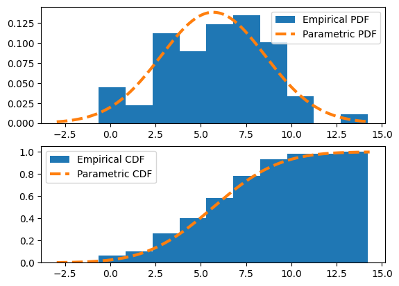

```python
#Flood frequency analysis
#Vannføring (m³/s) Middelflom;400 - middleflom gives to few values above threshold..
#vf1_over_400_by_year = vf1[vf1["Vannføring"] >= 300].resample("Y").max()
#vf2_over_400_by_year = vf2[vf2["Vannføring"] >= 300].resample("Y").max()
#vf3_over_400_by_year = vf3[vf3["Vannføring"] >= 300].resample("Y").max()

#Thresholds:
#Min two pr year.
#Value shoudl not be higher than the minimum value of the annual max series.
#print('Minperiode2:', vf1_annual_max['Vannføring'].min()) #
#print('Min periode 1:', vf2_annual_max['Vannføring'].min())
#print(vf3_annual_max.min())

#Threshold at 220 m3/s.
vf1_over_400 = vf1[vf1["Vannføring"] >= 220]
vf2_over_400 = vf2[vf2["Vannføring"] >= 220]
vf3_over_400 = vf3[vf3["Vannføring"] >= 220]

#print("\nAnnual maximum series for vf1 (1991-2020):")
#print(vf1_over_400.head())
#print(vf2_over_400.head())
#print(vf3_over_400.head())
#print("\nAnnual maximum series for vf2 (1961-1990):")
#print(vf2_annual_max)


#Resample to daily frequency to identify flood events
daily = vf3_over_400["Vannføring"].resample("D").agg(
    Count="count",
    Vannføring="first"   # or "last", same result if only one per day
)

daily = daily[daily["Count"] > 0]

print('Number of days where disharge is > 220', daily)

#Do the mann-kendal test??
#plt.plot(daily)


#Identidy consecutive days with flood events
#daily['Group'] = (daily['Count'].diff() != 1).cumsum()
groups = (daily.index.to_series().diff().dt.days != 1).cumsum()
daily["group"] = groups

streaks = daily.groupby("group")
print(streaks)

for g, df in streaks:
    print(f"Streak {g}: {df.index.min().date()} → {df.index.max().date()} ({len(df)} days)")


#Ok... then I will extract the maximum flood value for each streak
#streaks_max = streaks['Vannføring'].max().reset_index()
#streaks_max.rename(columns={'Vannføring': 'Max_Vannføring'}, inplace=True


def max_date(s):
    return s.idxmax()

streak_summary = daily.groupby("group").agg(
    start_date=("Vannføring", lambda s: s.index.min()),
    end_date=("Vannføring", lambda s: s.index.max()),
    max_vannføring=("Vannføring", "max"),
    max_date=("Vannføring", max_date)
).reset_index(drop=True)

# Final result: streak_summary
print(streak_summary)
print(streak_summary.columns)

streak_summary["Year"] = streak_summary["start_date"].dt.year

floods_per_year = (
    streak_summary.groupby("Year")
    .size()
    .reset_index(name="Number_of_floods")
)

print(floods_per_year)

#Ok...

plt.plot(floods_per_year['Number_of_floods'])

#Plot the normal distribution curve and check how our generated sample fit the curve

population_mean = floods_per_year['Number_of_floods'].mean()
population_std = floods_per_year['Number_of_floods'].std()
samplesize= len(floods_per_year)

print("Mean vf3 annual max:", population_mean)
print("Std vf3 annual max:", population_std)

rv1 = np.random.normal(loc=population_mean, scale=population_std, size=samplesize)

fig=plt.figure()
ax1=fig.add_subplot(211) #for pdfs
ax2=fig.add_subplot(212, sharex=ax1) #for cdfs

ax1.hist(rv1, density = True, label='Empirical PDF')
ax2.hist(rv1, density = True, cumulative=True, label='Empirical CDF')

# To plot the underlaying Gaussian, we use the stats package
x = np.linspace(population_mean-3*population_std,population_mean+3*population_std,1000)
ax1.plot(x, stats.norm.pdf(x, population_mean, population_std), '--', linewidth=3, label='Parametric PDF')
ax1.legend()

ax2.plot(x, stats.norm.cdf(x, population_mean, population_std), '--', linewidth=3, label='Parametric CDF')
ax2.legend()
```

## Is the number of floods also increasing?

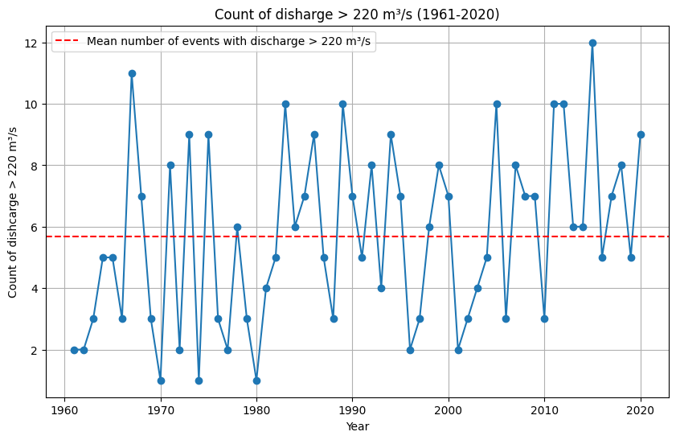

```
                            OLS Regression Results
==============================================================================
Dep. Variable:                      Q   R-squared:                       0.111
Model:                            OLS   Adj. R-squared:                  0.096
Method:                 Least Squares   F-statistic:                     7.245
Date:                Thu, 20 Nov 2025   Prob (F-statistic):            0.00927
Time:                        19:03:44   Log-Likelihood:                -144.54
No. Observations:                  60   AIC:                             293.1
Df Residuals:                      58   BIC:                             297.3
Df Model:                           1
Covariance Type:            nonrobust
==============================================================================
                 coef    std err          t      P>|t|      [0.025      0.975]
------------------------------------------------------------------------------
Intercept   -103.6587     40.623     -2.552      0.013    -184.975     -22.342
Y              0.0549      0.020      2.692      0.009       0.014       0.096
==============================================================================
Omnibus:                        3.986   Durbin-Watson:                   2.283
Prob(Omnibus):                  0.136   Jarque-Bera (JB):                2.721
Skew:                           0.349   Prob(JB):                        0.257
Kurtosis:                       2.225   Cond. No.                     2.29e+05
==============================================================================

Notes:
[1] Standard Errors assume that the covariance matrix of the errors is correctly specified.
[2] The condition number is large, 2.29e+05. This might indicate that there are
strong multicollinearity or other numerical problems.
```

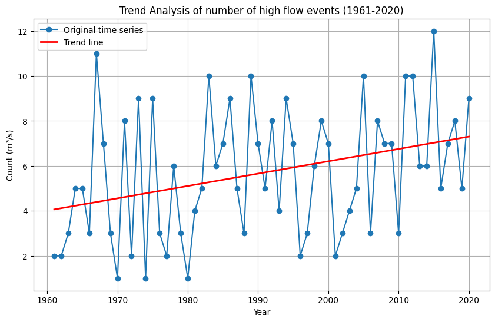

```
P-values for the coefficients:
Intercept    0.013378
Y            0.009274
dtype: float64
Coefficients:
 Intercept   -103.658664
Y              0.054932
dtype: float64
t-values:
 Intercept   -2.551705
Y            2.691711
dtype: float64
p-values:
 Intercept    0.013378
Y            0.009274
dtype: float64
F-statistic: 7.245305616844821
F-test p-value: 0.009274333075916009
                    0          1
Intercept -184.975013 -22.342316
Y            0.014081   0.095783
```

```python
#data = floods_per_year


mean = floods_per_year["Number_of_floods"].mean()
year = floods_per_year["Year"]

#print(mean, year)

plt.figure(figsize=(10,6))
plt.plot(year, floods_per_year["Number_of_floods"], marker='o', linestyle='-')
plt.axhline(y=mean, color='r', linestyle='--', label='Mean number of events with discharge > 220 m³/s')
plt.xlabel("Year")
plt.ylabel("Count of dishcarge > 220 m³/s")
plt.title("Count of disharge > 220 m³/s (1961-2020)")
plt.legend()
plt.grid(True)
plt.show()

#Investigate if there is a trend in the annual maximum series.

Q = floods_per_year["Number_of_floods"]
Y = floods_per_year["Year"]

#Fit model
model = ols("Q ~ Y", floods_per_year).fit()
print(model.summary())
#What to look for: Coef(slope) p-value < 0.05 indicates a significant trend. If p < a (commonly 0.05 we reject H0


trend = model.predict(floods_per_year)

plt.figure(figsize=(10,6))
plt.plot(Y, Q, marker='o', linestyle='-', label='Original time series')
plt.plot(Y, trend, color='red', linewidth=2, label='Trend line')
plt.xlabel("Year")
plt.ylabel("Count (m³/s)")
plt.title("Trend Analysis of number of high flow events (1961-2020)")
plt.legend()
plt.grid(True)
plt.show()


p_values = model.pvalues
print("P-values for the coefficients:")
print(p_values)

#Extract p-values and t-stats programmtaically
print("Coefficients:\n", model.params)
print("t-values:\n", model.tvalues)
print("p-values:\n", model.pvalues)

# Overall model F-test p-value
print("F-statistic:", model.fvalue)
print("F-test p-value:", model.f_pvalue)

print(model.conf_int(alpha=0.05))  # 95% CI by default
#H0: no trend (slope=0)
#H1: there is a trend (slope different from 0)

#mean = vf3_annual_max["Vannføring"].mean()
```

```python
#Mann-Kendall test for trend detection
import pymannkendall as mk
import statsmodels.api as sm

Q = floods_per_year["Number_of_floods"]
mk_result = mk.original_test(Q)
print(mk_result)


#result = mk(floods_per_year["Number_of_floods"])
#print(result)
```

```
Mann_Kendall_Test(trend='increasing', h=np.True_, p=np.float64(0.008594495871693919), z=np.float64(2.62777651687562), Tau=np.float64(0.23163841807909605), s=np.float64(410.0), var_s=np.float64(24225.333333333332), slope=np.float64(0.058823529411764705), intercept=np.float64(3.764705882352941))
```

```python
#But... does it really make sense to do flood frequency analysis on only 30 years of data? Or should we all data including 1961-1990 and then compare with results when including  period from 1991-2020?
#Ask Kolbjørn...?
```

```python
#What is the probability of getting 4 (or 5) 20 year flood in 8 years?
#For Voss er det ventet at flomvannføringene vil øke med 40 prosent i år 2100.
```

```python
from scipy.stats import binom

n = 8  # number of trials (years)
p = 1/20  # probability of success (20-year flood in a given year)
k = 5 # number of successes (floods)
i_5floods = binom.pmf(k, n, p)

print(i_5floods)
```

```
1.50040625e-05
```